# HR Analytics: Employee Churn Prediction

## Project Objective

The objective of this project is to use employee data and machine learning to predict whether an employee is likely to leave the organization. The project demonstrates how machine learning can be integrated into HR operations to support proactive employee retention and workforce planning.

## 1. Business Problem

Employee turnover can create significant challenges for organizations, including recruitment costs, training costs, loss of organizational knowledge, and workforce disruption.

From an HR perspective, identifying employees who may be at a higher risk of leaving can help organizations take proactive retention measures.

In this project, employee data is analyzed and a machine learning classification model is developed to predict employee churn.

### Key HR Question

Can employee characteristics such as satisfaction, performance evaluation, number of projects, working hours, tenure, salary, department, and promotion history be used to predict employee churn?

## 2. Dataset Introduction

The dataset contains employee-level information related to job satisfaction, performance evaluation, workload, tenure, work accidents, promotions, department, salary, and employee churn.

The target variable is `churn`, which indicates whether an employee left the organization.

The remaining variables are used as potential predictors of employee churn.

```python
# Import libraries required for data analysis and visualization

import pandas as pd
import numpy as np
import matplotlib.pyplot as plt
import seaborn as sns
```

```python
# Find the CSV file automatically
csv_file = [file for file in os.listdir() if file.lower().endswith(".csv")][0]

# Display the filename Python found
print(csv_file)
```

```
employee churn dataset for datacmp project.csv
```

```python
# Load the employee churn dataset
data = pd.read_csv(csv_file)

# Display the first five rows
data.head()
```

|  | satisfaction | evaluation | number_of_projects | average_montly_hours | time_spend_company | work_accident | churn | promotion | department | salary |
| --- | --- | --- | --- | --- | --- | --- | --- | --- | --- | --- |
| 0 | 0.38 | 0.53 | 2 | 157 | 3 | 0 | 1 | 0 | sales | low |
| 1 | 0.80 | 0.86 | 5 | 262 | 6 | 0 | 1 | 0 | sales | medium |
| 2 | 0.11 | 0.88 | 7 | 272 | 4 | 0 | 1 | 0 | sales | medium |
| 3 | 0.72 | 0.87 | 5 | 223 | 5 | 0 | 1 | 0 | sales | low |
| 4 | 0.37 | 0.52 | 2 | 159 | 3 | 0 | 1 | 0 | sales | low |

## 3. Data Understanding

Before performing analysis and developing the prediction model, the dataset is examined to understand its structure, variables, data types, and overall quality.

```python
# Display the first five rows of the dataset
data.head()

# Display the last five rows of the dataset
data.tail()

# Check the dimensions of the dataset
print("Number of rows:", data.shape[0])
print("Number of columns:", data.shape[1])
```

```
Number of rows: 14999
Number of columns: 10
```

```python
# Display all column names
data.columns
```

```
Index(['satisfaction', 'evaluation', 'number_of_projects',
       'average_montly_hours', 'time_spend_company', 'work_accident', 'churn',
       'promotion', 'department', 'salary'],
      dtype='object')
```

```python
# Display information about columns, data types, and missing values
data.info()
```

```
<class 'pandas.core.frame.DataFrame'>
RangeIndex: 14999 entries, 0 to 14998
Data columns (total 10 columns):
 #   Column                Non-Null Count  Dtype
---  ------                --------------  -----
 0   satisfaction          14999 non-null  float64
 1   evaluation            14999 non-null  float64
 2   number_of_projects    14999 non-null  int64
 3   average_montly_hours  14999 non-null  int64
 4   time_spend_company    14999 non-null  int64
 5   work_accident         14999 non-null  int64
 6   churn                 14999 non-null  int64
 7   promotion             14999 non-null  int64
 8   department            14999 non-null  object
 9   salary                14999 non-null  object
dtypes: float64(2), int64(6), object(2)
memory usage: 1.1+ MB
```

```python
# Generate descriptive statistics for numerical variables
data.describe()
```

|  | satisfaction | evaluation | number_of_projects | average_montly_hours | time_spend_company | work_accident | churn | promotion |
| --- | --- | --- | --- | --- | --- | --- | --- | --- |
| count | 14999.000000 | 14999.000000 | 14999.000000 | 14999.000000 | 14999.000000 | 14999.000000 | 14999.000000 | 14999.000000 |
| mean | 0.612834 | 0.716102 | 3.803054 | 201.050337 | 3.498233 | 0.144610 | 0.238083 | 0.021268 |
| std | 0.248631 | 0.171169 | 1.232592 | 49.943099 | 1.460136 | 0.351719 | 0.425924 | 0.144281 |
| min | 0.090000 | 0.360000 | 2.000000 | 96.000000 | 2.000000 | 0.000000 | 0.000000 | 0.000000 |
| 25% | 0.440000 | 0.560000 | 3.000000 | 156.000000 | 3.000000 | 0.000000 | 0.000000 | 0.000000 |
| 50% | 0.640000 | 0.720000 | 4.000000 | 200.000000 | 3.000000 | 0.000000 | 0.000000 | 0.000000 |
| 75% | 0.820000 | 0.870000 | 5.000000 | 245.000000 | 4.000000 | 0.000000 | 0.000000 | 0.000000 |
| max | 1.000000 | 1.000000 | 7.000000 | 310.000000 | 10.000000 | 1.000000 | 1.000000 | 1.000000 |

```python
# Check the number of missing values in each column
data.isnull().sum()
```

```
satisfaction            0
evaluation              0
number_of_projects      0
average_montly_hours    0
time_spend_company      0
work_accident           0
churn                   0
promotion               0
department              0
salary                  0
dtype: int64
```

## 4. Employee Churn Analysis

Before developing the prediction model, it is important to understand the distribution of employee churn in the dataset.

```python
# Count employees who stayed and employees who churned
data["churn"].value_counts()
```

```
churn
0    11428
1     3571
Name: count, dtype: int64
```

```python
# Calculate the percentage distribution of employee churn
n_employees = len(data)

print(data.churn.value_counts())
print(data.churn.value_counts() / n_employees * 100)
```

```
churn
0    11428
1     3571
Name: count, dtype: int64
churn
0    76.191746
1    23.808254
Name: count, dtype: float64
```

## 5. Correlation Analysis

Correlation analysis is used to examine the relationships between numerical employee variables and identify variables that may have an association with employee churn. Correlation does not imply causation, but it can provide useful insights for further analysis and model development.

```python
# Calculate the correlation matrix for numerical variables
corr_matrix = data.corr(numeric_only=True)
corr_matrix
```

|  | satisfaction | evaluation | number_of_projects | average_montly_hours | time_spend_company | work_accident | churn | promotion |
| --- | --- | --- | --- | --- | --- | --- | --- | --- |
| satisfaction | 1.000000 | 0.105021 | -0.142970 | -0.020048 | -0.100866 | 0.058697 | -0.388375 | 0.025605 |
| evaluation | 0.105021 | 1.000000 | 0.349333 | 0.339742 | 0.131591 | -0.007104 | 0.006567 | -0.008684 |
| number_of_projects | -0.142970 | 0.349333 | 1.000000 | 0.417211 | 0.196786 | -0.004741 | 0.023787 | -0.006064 |
| average_montly_hours | -0.020048 | 0.339742 | 0.417211 | 1.000000 | 0.127755 | -0.010143 | 0.071287 | -0.003544 |
| time_spend_company | -0.100866 | 0.131591 | 0.196786 | 0.127755 | 1.000000 | 0.002120 | 0.144822 | 0.067433 |
| work_accident | 0.058697 | -0.007104 | -0.004741 | -0.010143 | 0.002120 | 1.000000 | -0.154622 | 0.039245 |
| churn | -0.388375 | 0.006567 | 0.023787 | 0.071287 | 0.144822 | -0.154622 | 1.000000 | -0.061788 |
| promotion | 0.025605 | -0.008684 | -0.006064 | -0.003544 | 0.067433 | 0.039245 | -0.061788 | 1.000000 |

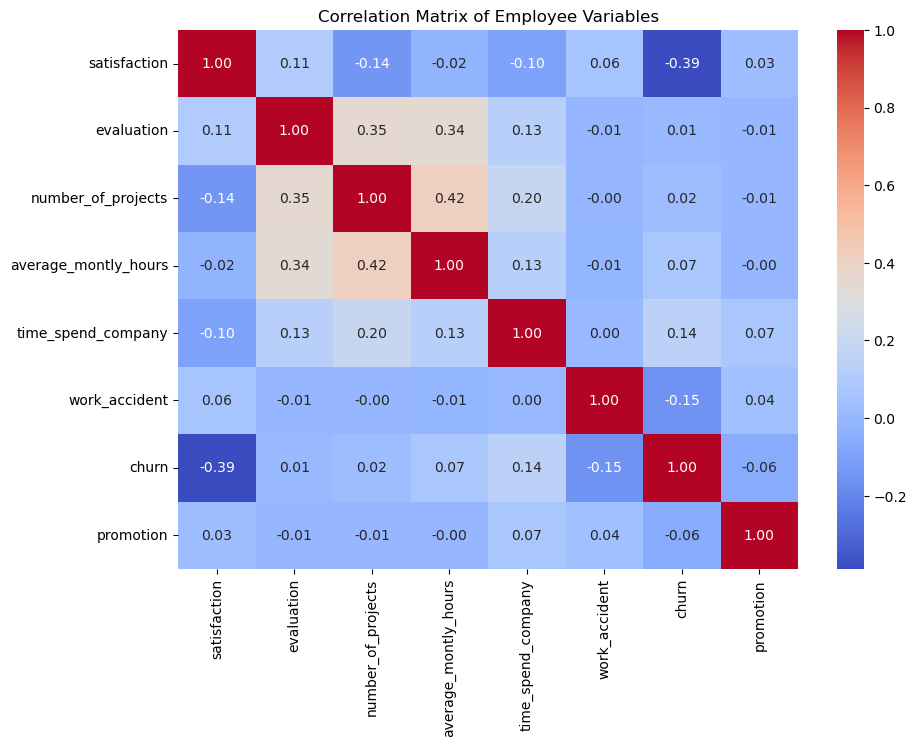

```python
# Visualize the correlation matrix
plt.figure(figsize=(10, 7))
sns.heatmap(
    corr_matrix,
    annot=True,
    cmap="coolwarm",
    fmt=".2f"
)
plt.title("Correlation Matrix of Employee Variables")
plt.show()
```

## 6. Encoding Categorical Variables

Machine learning models require numerical inputs. Therefore, the categorical variables in the dataset need to be converted into numerical representations. Salary has a natural order: Low < Medium < High Therefore, salary is treated as an ordinal categorical variable.

```python
# Convert salary into an ordered categorical variable
data["salary"] = pd.Categorical(
    data["salary"],
    categories=["low", "medium", "high"],
    ordered=True)

# Convert the ordered categories into numerical codes
# low = 0, medium = 1, high = 2
data["salary"] = data["salary"].cat.codes
```

```python
# Create dummy variables for department
department = pd.get_dummies(
    data["department"],
    dtype=int
)
department.head()
```

[output not shown]

```python
# Remove the original categorical department column
data = data.drop("department", axis=1)
```

```python
# Add the encoded department variables to the dataset
data = data.join(department)
```

## 7. Defining the Target and Features

The machine learning problem is formulated as a binary classification task.

### Target Variable

`churn` represents whether an employee left the organization.

### Features

All remaining employee characteristics are used as potential predictors of churn.

```python
# Define the target variable
target = data["churn"]
```

```python
# Define the predictor variables
features = data.drop("churn", axis=1)
```

## 8. Train-Test Split

The dataset is divided into training and testing sets.

The training data is used to develop the machine learning model, while the testing data is used to evaluate how well the model performs on previously unseen employee records.

A test size of 25% is used, meaning 75% of the observations are used for training and 25% for testing.

```python
# Import the train-test split function
from sklearn.model_selection import train_test_split

# Split the data into training and testing sets
features_train, features_test, target_train, target_test = train_test_split(
    features,
    target,
    test_size=0.25,
    random_state=42,
    stratify=target
)
```

## 9. Decision Tree Classification

A Decision Tree Classifier is used to predict employee churn.

The model works by creating a series of decision rules based on employee characteristics and dividing employees into groups with similar churn outcomes.The Gini impurity criterion is used to determine the quality of each split.

```python
# Import the Decision Tree classifier
from sklearn.tree import DecisionTreeClassifier

# Create the Decision Tree model
model = DecisionTreeClassifier(
    criterion="gini",
    max_depth=5,
    random_state=42
)
```

```python
# Convert salary from categorical to numerical
features_train["salary"] = features_train["salary"].cat.codes
```

```python
features_test["salary"] = features_test["salary"].cat.codes
```

```python
model.fit(features_train, target_train)
```

```
DecisionTreeClassifier(max_depth=5, random_state=42)
```

```python
# Compare training and testing accuracy
train_accuracy = model.score(features_train, target_train)
test_accuracy = model.score(features_test, target_test)

print("Training Accuracy:", round(train_accuracy * 100, 2), "%")
print("Testing Accuracy :", round(test_accuracy * 100, 2), "%")
```

```
Training Accuracy: 97.53 %
Testing Accuracy : 97.6 %
```

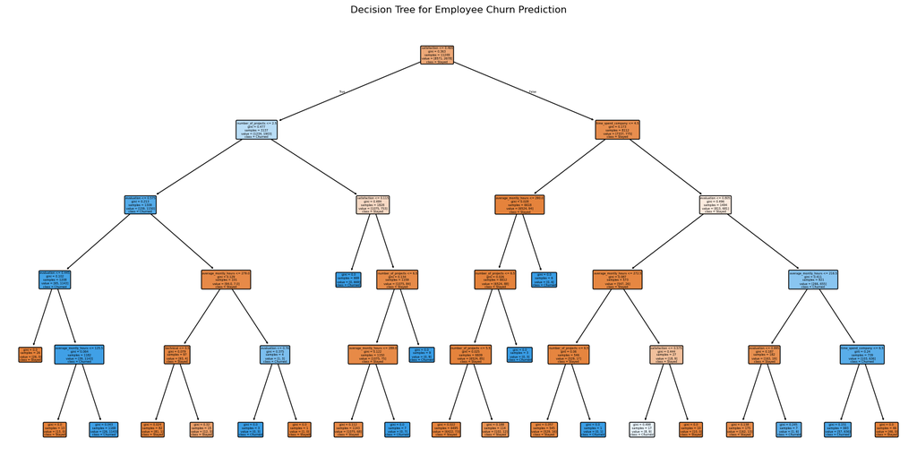

```python
# Import tools for visualizing the decision tree
from sklearn.tree import plot_tree
plt.figure(figsize=(20, 10))
plot_tree(
    model,
    feature_names=features.columns,
    class_names=["Stayed", "Churned"],
    filled=True,
    rounded=True
)
plt.title("Decision Tree for Employee Churn Prediction")
plt.show()
```

## 12. Feature Importance

Feature importance indicates how useful each employee characteristic was in the decision tree's prediction process.

This can help translate the machine learning output into potentially useful HR insights.

```python
feature_importance = pd.DataFrame({
    "Feature": features.columns,
    "Importance": model.feature_importances_
})
feature_importance = feature_importance.sort_values(
    by="Importance",
    ascending=False
)
feature_importance
```

|  | Feature | Importance |
| --- | --- | --- |
| 0 | satisfaction | 0.538030 |
| 4 | time_spend_company | 0.153972 |
| 1 | evaluation | 0.144354 |
| 2 | number_of_projects | 0.100422 |
| 3 | average_montly_hours | 0.062970 |
| 17 | technical | 0.000251 |
| 6 | promotion | 0.000000 |
| 7 | salary | 0.000000 |
| 8 | IT | 0.000000 |
| 5 | work_accident | 0.000000 |
| 10 | accounting | 0.000000 |
| 11 | hr | 0.000000 |
| 12 | management | 0.000000 |
| 13 | marketing | 0.000000 |
| 14 | product_mng | 0.000000 |
| 15 | sales | 0.000000 |
| 16 | support | 0.000000 |
| 9 | RandD | 0.000000 |

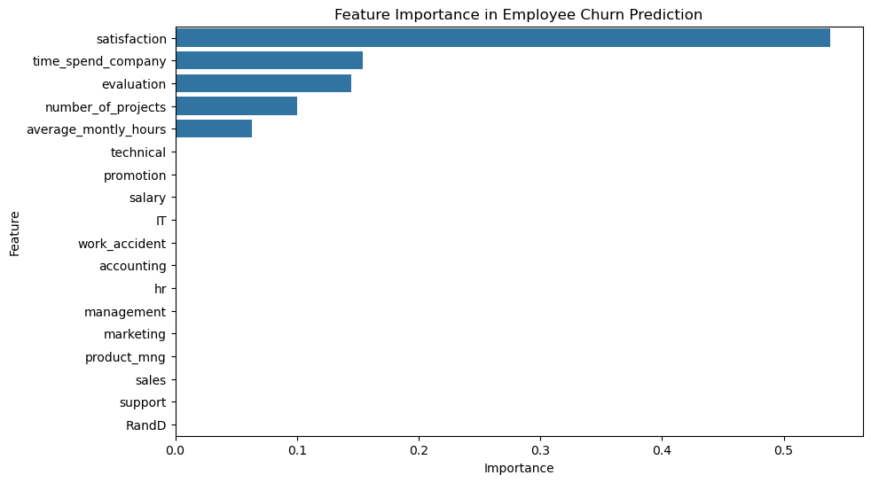

```python
# Visualize feature importance
plt.figure(figsize=(10, 6))
sns.barplot(
    data=feature_importance,
    x="Importance",
    y="Feature"
)

plt.title("Feature Importance in Employee Churn Prediction")
plt.xlabel("Importance")
plt.ylabel("Feature")
plt.show()
```

## 13. HR Interpretation

The machine learning model provides HR with a data-driven approach to identifying patterns associated with employee churn.

The results can potentially support:

- Proactive employee retention initiatives
- Workforce planning
- Identification of areas requiring employee engagement interventions
- Review of workload and working-hour patterns
- Evaluation of compensation and promotion practices

The model should be considered a decision-support tool rather than a replacement for HR judgement.

## 14. HR Recommendations

Based on the model results, HR can consider using employee churn predictions as an early-warning mechanism.

Potential applications include:

1. Identifying employee groups that may require greater retention attention.
2. Reviewing employee satisfaction and workload patterns.
3. Strengthening employee engagement initiatives.
4. Evaluating opportunities for career development and promotion.
5. Using data-driven insights to support workforce planning.

Any intervention should be supported by appropriate HR judgement and additional employee-level context rather than relying solely on the model.

## 15. Conclusion

This project demonstrates how machine learning can be applied to an HR problem such as employee churn prediction.

A Decision Tree classification model was developed using employee characteristics to predict whether an employee is likely to leave the organization.

The project demonstrates the potential of integrating data analytics and machine learning into HR processes to support proactive retention, workforce planning, and evidence-based decision-making.